# Data Viz Homework 4

Author

Olivia Holt

# Data

From Kaggle:

https://www.kaggle.com/datasets/mikeshout/14erpeaks/data

### **Context**

This tidy dataset lists mountain peaks rising to an elevation greater than 14,000 ft (4,267 meters) located in the state of Colorado, USA.

A fourteener is a mountain peak with an elevation greater than 14,000 feet and a significant prominence. The prominence has to be at least 300 feet higher than the saddle connecting it to a neighboring peak.

In Colorado, and in this dataset, there are 58 peaks over 14,000 feet. Although five of those peaks do not meet the prominence rule but are included in this dataset.

**Parameters of interest:**

- **Traffic High** – The high range of estimated visits in the year 2017
- **Lat** -The latitudinal coordinate in decimal form
- **Long** - The longitudinal coordinate in decimal form
- **Mountain Peak** – The name of the peak
- **Elevation Gain_ft** – The elevation gain of the standard route in feet
- **Difficulty** – The Yosemite Decimal System difficulty rating, a value ranging from Class 1 (easiest), Class 2, Easy Class 3, Class 3, Hard Class3, to Class 4 (most difficult)
- **Prominence_ft** – How much higher the peak is in feet from the next highest point

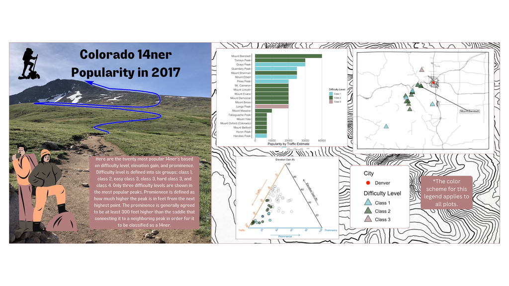

```r
#| eval: true
#| echo: false
#| fig-align: "center"
#| out-width: "100%"
#| fig-alt: "Alt text here"
knitr::include_graphics(here::here("Colorado14nerPopularity.png"))
```

# Load Libraries

```r
# load in libraries ----
library(tidyverse)
library(janitor)
library(dplyr)
library(ggplot2)
library(maps)
library(plotly)
library(kableExtra)
library(paletteer)
library(maps)
library(mapdata)
library(ggmap)
library(osmdata)
library(grid)
library(viridis)
library(ggtern)
```

# Load in Data

```r
data_wd <- "/Users/oliviaholt/Documents/eds240/Holt-eds240-HW4/data"
# import data ----
fourteener_data <- read_csv(file.path(data_wd, "14er.csv"), show_col_types = FALSE)
```

# Clean Data

```r
# clean data names----
fourteener_clean <- fourteener_data %>%
  clean_names()

# I want the difficulty class to be a value from 1 to 6 which I will change here
fourteener_clean <- fourteener_clean %>%
  mutate(
    new_difficulty = case_when(
      difficulty == "Class 1" ~ 1,
      difficulty == "Class 2" ~ 2,
      difficulty == "Hard Class 2" ~ 3,
      difficulty == "Easy Class 3" ~ 4,
      difficulty == "Class 3" | difficulty == "Hard Class 3" ~ 5,
      difficulty == "Class 4" ~ 6,
      TRUE ~ 20
    )
  )

# I also want to arrange by descending order for taffic_high for viewing purposes
fourteener_clean <- fourteener_clean %>% arrange(traffic_high)

#grabbign the 20 most visited peaks into a subset
fourteener_20 <- fourteener_clean %>%
  tail(20)
```

# Bar Plot

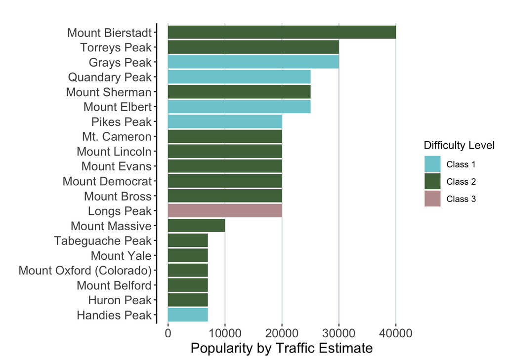

```r
#use subset of top 20 most visited peaks
col_plot <- fourteener_clean %>%
  tail(20) %>%
  ggplot() +
  geom_col(aes(y = reorder(mountain_peak, traffic_high), #change into ascending order for mountain peak by traffic
               x = traffic_high, fill = difficulty))+
  xlab("Popularity by Traffic Estimate") +
  ylab("")+ #empty ylabel
  ggtitle(" ")+ #empty title
  #get rid of grey background and fill with white
  theme(panel.background = element_rect(fill = "white"),
        #creating horizontal axis grid lines
        panel.grid.major.x = element_line(color = "#A8BAC4", size = 0.3),
        # Only left line of the vertical axis is painted in black
        axis.line.y.left = element_line(color = "black"),
        # increase font size for x and y-axis labels
        axis.text.x = element_text(size = 12, family = "Arial"),
        axis.text.y = element_text(size = 12, family = "Arial"),
        axis.title.x = element_text(size = 14,family = "Arial"))+
  scale_fill_paletteer_d("nationalparkcolors::CraterLake")+
  labs(fill = "Difficulty Level")  # Change the legend title here

col_plot
```

```r
#ggsave("col_plot.png", plot = col_plot, device = "png", width = 8, height = 6)
```

# Ternary Plot

```r
#showing all 58 14ner's color coded by difficulty

# Create a ternary plot with specified axis limits
tern_plot_0 <- ggtern(data = fourteener_clean,
                       aes(x = traffic_high,
                           y = elevation_gain_ft,
                           z = prominence_ft,
                           fill = difficulty)) +#fill color by difficulty

  # Adding points to the plot with adjustements to transparancy, shape, color, size
  geom_point(alpha = 0.5, shape = 21, color = "black", size = 4) +

  # Apply a theme to the plot
  theme_bvbw(base_size = 12) +

  # Adjust the legend position
  theme(legend.position = "bottom",axis.title = element_text(size = 9)) +

  # Labeling the axes
  ylab("Elevation Gain (ft)") +
  xlab("Traffic") +
  zlab("Prominence") +

  # Setting the title of the plot as empty
  labs(title = " ")+

   # Customizing the legend title and appearance
   guides(fill = guide_legend(title = "Difficulty Level")) + #legend title
   theme(legend.key = element_rect(fill = "white", color = "white"), #background color
         legend.title = element_text(size = 10))+  # customizing legend box color
   #Customize the legend title and appearance

  # Use scale_fill_manual to set custom colors for each difficulty level
  #based off of the CraterLake color palette colors
  scale_fill_manual(values = c("Class 1" = "#7DCCD3FF", "Class 2" = "#4E7147FF",
                               "Easy Class 3" = "#BE9C9DFF", "Class 3" = "#F7ECD8FF",
                               "Hard Class 3" = "#376597FF", "Class 4" = "#9888A5FF"))
```

```r
# a subset plot to only look at the 20 most popular 14ner in 2017
# Creating a ternary plot
tern_plot <- ggtern(data = fourteener_20,
                       aes(x = traffic_high,
                           y = elevation_gain_ft,
                           z = prominence_ft,
                           fill = difficulty)) +

  # Add points to the plot with specified attributes
  geom_point(alpha = 0.8, shape = 21, color = "black", size = 4) +

  # Apply a theme to the plot
  theme_bvbw(base_size = 12) +

  # Adjust the legend position
  theme(legend.position = "bottom",axis.title = element_text(size = 9)) +

  # Label the axes
  ylab("Elevation Gain (ft)") +
  xlab("Traffic") +
  zlab("Prominence") +

  # Set the title of the plot as empty
  labs(title = " ")+

   # Customize the legend title and appearance
   guides(fill = guide_legend(title = "Difficulty Level")) +
   theme(legend.key = element_rect(fill = "white", color = "white"),
         legend.title = element_text(size = 10))+  # customizing legend box color
   #Customize the legend title and appearance

  # Using scale_fill_manual to set custom colors for each difficulty level
  scale_fill_manual(values = c("Class 1" = "#7DCCD3FF", "Class 2" = "#4E7147FF",
                               "Easy Class 3" = "#BE9C9DFF", "Class 3" = "#F7ECD8FF",
                               "Hard Class 3" = "#376597FF", "Class 4" = "#9888A5FF"))
```

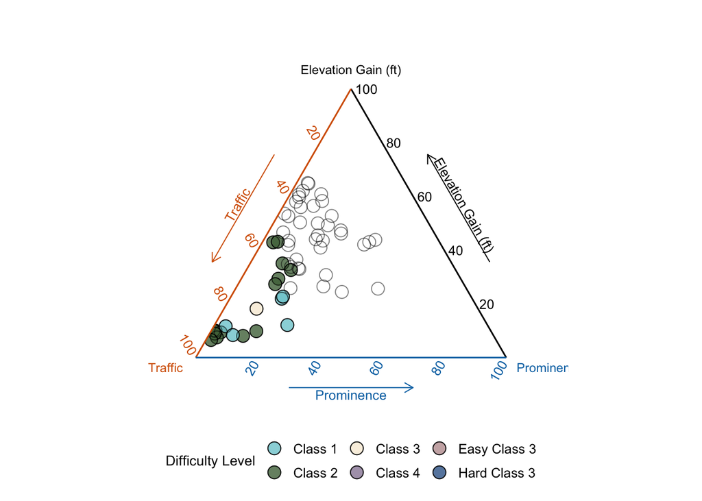

```r
# Add points to show where the other 38 fourteeners are
#focus on most popular 20
tern_plot_2 <- tern_plot +
  geom_point(data = fourteener_clean, alpha = 0.5, shape = 1, color = "black", size = 4, family = "Arial") # changing transparancy, shape, color, size and font

tern_plot_2 #printing plot
```

```r
ggsave("tern_plot_2.png", plot = tern_plot_2, device = "png", width = 8, height = 6)
```

# **Map**

Note: I used the OSM package to plot major highways but could not render with it. Therefore I left it commented out because I still used it in the infographic.

```r
# load United States state map data from map_data package
MainStates <- map_data("state")
st_CO <- MainStates %>%
  filter(region == "colorado")

# #using the OSM package to view the main roads in colorado
# big_streets <- getbb("Colorado United States")%>%
#   opq()%>%
#   add_osm_feature(key = "highway",
#                   value = c("motorway", "primary", "motorway_link", "primary_link")) %>%
#   osmdata_sf()
```

```r
# Filter the mt. bierstadt in the dataset (most visited)
mt_bierstadt <- tail(fourteener_20, 1)

map_plot_2 <- ggplot() +
  geom_polygon(data = st_CO, aes(x = long, y = lat, group = group),
               color = "black", fill = "white") +
  #geom_sf(data = big_streets$osm_lines, color = "black", alpha = 0.25) +
  geom_point(data = fourteener_20,
             aes(x = long, y = lat, fill = difficulty),
             alpha = 0.8, shape = 24, color = "black", size = 5) +
  geom_label(data = mt_bierstadt,
             aes(x = long + 0.1, y = lat + 0.1, label = mountain_peak),#labeling the Mt. Bierstadt
             vjust = 1.5, size = 3, color = "black",
             label.padding = unit(0.15, "lines"),  # Adjust label padding
             label.r = unit(0.15, "lines"),         # Adjust label radius
             label.size = 0.25,#adjusting label size
             nudge_x = 2.5,  # Nudging the labels to the right
             nudge_y = -1) +  # Nudging the labels up
  geom_segment(data = mt_bierstadt,
               aes(x = long, y = lat, xend = long + 2.5, yend = lat + -1),# adjusting the location of the text box label for Mt. Biestadt
               color = "black", size = 0.5, alpha = 1, lineend = "round") +  # Adding connecting line to mt bierstadt
  scale_fill_paletteer_d("nationalparkcolors::CraterLake", name = "Difficulty Level") +
  labs(title = "") +  # Empty title
  theme(axis.title.x = element_blank(),  # Remove x-axis title
        axis.title.y = element_blank(),  # Remove y-axis title
        axis.text.x = element_blank(),   # Remove x-axis labels
        axis.text.y = element_blank(),   # Remove y-axis labels
        axis.ticks.x = element_blank(),   # Remove x-axis ticks
        axis.ticks.y = element_blank())+   # Remove y-axis ticks
  theme_void()# changing theme to void
```

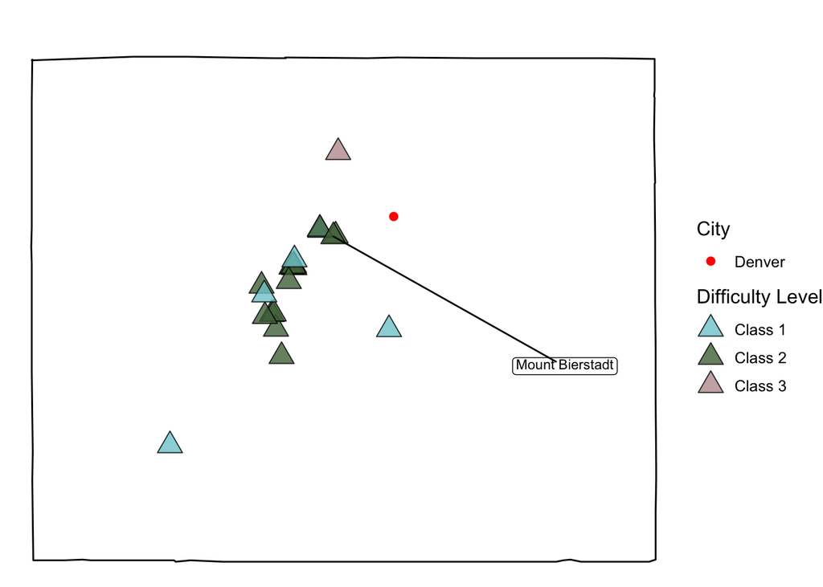

```r
# Coordinates for Denver
denver_lat <- 39.742043
denver_long <- -104.991531

# Add Denver point to the plot with a specific color
map_plot_den <- map_plot_2 +
  geom_point(data = data.frame(lon = denver_long, lat = denver_lat),
             aes(x = lon, y = lat, color = "Denver"), size = 2) +
  scale_color_manual(values = "red", name = "City") #Using a red dot to pinpoint Denver

# Print the plot
map_plot_den
```

```r
#ggsave("map_plot_den.png", plot = map_plot_den, device = "png", width = 8, height = 6)
```

# Write Up

My question is ‘What makes a fourteener (14ner) the most popular’? With this dataset in particular I am looking at elevation gain of the hike in feet, high traffic estimates for 2017, difficulty level of the hike, and the individual peaks. The dataset has average values for the entire year of 2017. The difficulty levels range from Class 1, Class 2, Easy Class 3, Class 3, Hard Class 3, and Class 4.

This tidy dataset is from Kaggle and it lists mountain peaks rising to an elevation greater than 14,000 ft (otherwise known as a fourteener) located in Colorado. Other than being 14,000 ft tall to be a 14ner, the prominence of the peak has to be at least 300 feet higher than the saddle that is connecting it to a neighboring peak. There are 58 peaks over 14,000 feet in Colorado and five of those peaks do not meet the prominence rule, but are included in this dataset. The dataset did not need much cleaning and wrangling except for some subsetting, arranging, and renaming.

Initially, I anticipated that elevation/elevation gain and difficulty level would have the highest impact on traffic estimates and therefore wanted to focus on those. In hindsight I wish I had found a data set that had the distances from each to Denver as I think that would have a high impact on the popularity. From living in Colorado I remember Mt. Bierstadt being a popular peak because of its accessibility from Denver and it being the ‘shortest’ 14ner. This also made it the most accessible for people visiting from out of state as it is closer to the airport in Denver and for people not used to the elevation. It also would have been interesting to look at trends for each season as not many people climb in the winter or fall.

Mt. Bierstadt did prove to be the most popular 14ner to climb in 2017 according to the high traffic estimate. When looking at the 20 most popular 14ner’s in 2017 they were all below the ‘Hard Class 3’ difficulty range according to the bar plot. Most of them were close together and closer to Denver, except for Handles peak in the southwest region of Colorado according to the map plot. And compared to the other 14ner’s, they had less elevation gain on the hike according to the ternary plot.

A column plot, map, and ternary plot were used to visualize this dataset. These plots were selected because it is important to see where the peaks are located in relation to each other and in relation to major cities (Denver). The bar plot is an easy to read visual representation to view high traffic for each 14ner. I chose to do a ternary plot as well because I wanted to try an advanced plot.

The titles and axis labels were changed for all of the plots along with an annotation and the axis tick changes on the map. The themes and palettes were changed to match so I only had to have one legend on the infographic and it would be easier to interpret all the plots together. The color palette I chose was a national park themed for crater lake. I tried to keep the plots as simple as possible so there wasn’t too much repeating information on the infographic. My primary message was to look at difficulty and elevation gain for the most popular hikes and I found that the hikes that were of lower elevation and lower difficulty were more popular. This makes sense to me because they are more accessible for a larger group of people. The plots I made were for a general audience and I think they would be understood by most people. I added the theme_bvbw() so that the ternary plot would be easier to read with added arrows to signify the direction of each variable’s proportions.

## References:

#### Photos:

https://www.14ers.com/route.php?route=bier1

https://topographiadesign.com/products/pikes-peak-colorado-topographic-print?variant=32432336175244